# Final project :Stock Price predictor¶

Predicting how the stock market will perform is one of the most difficult things to do. There are so many factors involved in the prediction – physical factors vs. psychological, rational and irrational behaviour, etc.

In this project we will work with historical data about the stock prices of a publicly listed stock price of this company like Microsoft ,Apple, Tesla

We’ll kick of by importing NumPy for scientific computation, Matplotlib for plotting graphs, and Pandas to aide in loading and manipulating our datasets.

```python
#import packages
import pandas as pd
import numpy as np


import seaborn as sns

#to plot within notebook
import matplotlib.pyplot as plt
%matplotlib inline

#setting figure size
from matplotlib.pylab import rcParams
rcParams['figure.figsize'] = 20,10

#for normalizing data
from sklearn.preprocessing import MinMaxScaler
scaler = MinMaxScaler(feature_range=(0, 1))

#import statsmodels.api as sm
```

```python
#Read the dataset
df=pd.read_csv('Stock_data.csv')
```

We check the head of our dataset to give us a glimpse into the kind of dataset we’re working with.

```python
df.head()
```

|  | Date | Open | High | Low | Close | Volume | OpenInt | Stock |
| --- | --- | --- | --- | --- | --- | --- | --- | --- |
| 0 | 1984-09-07 | 0.42388 | 0.42902 | 0.41874 | 0.42388 | 23220030 | 0 | AAPL |
| 1 | 1984-09-10 | 0.42388 | 0.42516 | 0.41366 | 0.42134 | 18022532 | 0 | AAPL |
| 2 | 1984-09-11 | 0.42516 | 0.43668 | 0.42516 | 0.42902 | 42498199 | 0 | AAPL |
| 3 | 1984-09-12 | 0.42902 | 0.43157 | 0.41618 | 0.41618 | 37125801 | 0 | AAPL |
| 4 | 1984-09-13 | 0.43927 | 0.44052 | 0.43927 | 0.43927 | 57822062 | 0 | AAPL |

The columns Open and Close represent the starting and final price at which the stock is traded on a particular day.

Another important thing to note is that the market is closed on weekends and public holidays.Notice the above table again, some date values are missing – 1984-09-08,1984-09-09, 8th and 9th fall on a weekend.

```python
df.shape
```

```
(19586, 8)
```

By using shape function we can find number of rows and columns

Let us see the data types of each of the columns to get an idea of the type of data we have

```python
df.info()
```

```
<class 'pandas.core.frame.DataFrame'>
RangeIndex: 19586 entries, 0 to 19585
Data columns (total 8 columns):
 #   Column   Non-Null Count  Dtype
---  ------   --------------  -----
 0   Date     19586 non-null  object
 1   Open     19586 non-null  float64
 2   High     19586 non-null  float64
 3   Low      19586 non-null  float64
 4   Close    19586 non-null  float64
 5   Volume   19586 non-null  int64
 6   OpenInt  19586 non-null  int64
 7   Stock    19586 non-null  object
dtypes: float64(4), int64(2), object(2)
memory usage: 1.2+ MB
```

'Date' column should be date-type we will convert it to date type using to_datetime() function

```python
#Check for missing values
df.isnull().sum()
```

```
Date       0
Open       0
High       0
Low        0
Close      0
Volume     0
OpenInt    0
Stock      0
dtype: int64
```

Looks like we have cleaned dataset means its good to go ahead

```python
df['Stock'].unique()
```

```
array(['AAPL', 'TSLA', 'MSFT', 'FB'], dtype=object)
```

The master dataset contain the data for various companies like Apple,Tesla,Facebook,Microsoft Out of this we will first choose Apple dataset for our analysis then we can do similar process for remaining companies also.

```python
apple_df=df.loc[df['Stock']=='AAPL']
apple_df.head()
```

|  | Date | Open | High | Low | Close | Volume | OpenInt | Stock |
| --- | --- | --- | --- | --- | --- | --- | --- | --- |
| 0 | 1984-09-07 | 0.42388 | 0.42902 | 0.41874 | 0.42388 | 23220030 | 0 | AAPL |
| 1 | 1984-09-10 | 0.42388 | 0.42516 | 0.41366 | 0.42134 | 18022532 | 0 | AAPL |
| 2 | 1984-09-11 | 0.42516 | 0.43668 | 0.42516 | 0.42902 | 42498199 | 0 | AAPL |
| 3 | 1984-09-12 | 0.42902 | 0.43157 | 0.41618 | 0.41618 | 37125801 | 0 | AAPL |
| 4 | 1984-09-13 | 0.43927 | 0.44052 | 0.43927 | 0.43927 | 57822062 | 0 | AAPL |

The Open column is the starting price while the Close column is the final price of a stock on a particular trading day. The High and Low columns represent the highest and lowest prices for a certain day.

The profit or loss calculation is usually determined by the closing price of a stock for the day, hence we will consider the closing price as the target variable. Let’s plot the target variable to understand how it’s shaping up in our data:

# Exploratory Data Analysis

Summary statistics

Let us start with getting the summary statistics on the given data

```python
apple_df.describe()
```

|  | Open | High | Low | Close | Volume | OpenInt |
| --- | --- | --- | --- | --- | --- | --- |
| count | 8364.000000 | 8364.000000 | 8364.000000 | 8364.000000 | 8.364000e+03 | 8364.0 |
| mean | 22.284350 | 22.495867 | 22.054244 | 22.281018 | 1.066416e+08 | 0.0 |
| std | 37.763402 | 38.057733 | 37.447432 | 37.764469 | 9.935187e+07 | 0.0 |
| min | 0.233050 | 0.235640 | 0.230510 | 0.230510 | 0.000000e+00 | 0.0 |
| 25% | 1.137100 | 1.164200 | 1.112800 | 1.137100 | 4.384365e+07 | 0.0 |
| 50% | 1.632800 | 1.663400 | 1.600600 | 1.628250 | 7.481383e+07 | 0.0 |
| 75% | 23.739000 | 23.930500 | 23.335750 | 23.694500 | 1.320534e+08 | 0.0 |
| max | 175.110000 | 175.610000 | 174.270000 | 175.610000 | 2.069770e+09 | 0.0 |

Describe() function will give us all necessary summary statistics of each column at one place

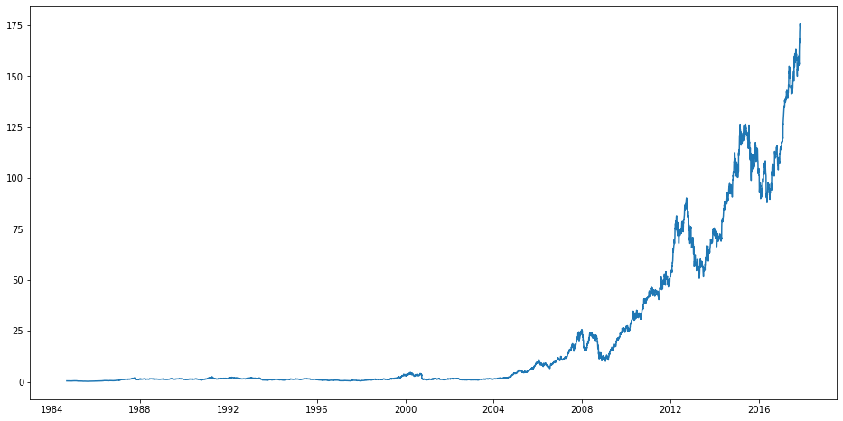

```python
#Setting index as date
apple_df['Date'] = pd.to_datetime(apple_df.Date,format='%Y-%m-%d')
apple_df.index = apple_df['Date']

#plot
plt.figure(figsize=(16,8))
plt.plot(apple_df['Close'], label='Close Price history')
```

# Building LSTM Model

Long Short Term Memory (LSTM) Introduction

LSTMs are widely used for sequence prediction problems and have proven to be extremely effective. The reason they work so well is because LSTM is able to store past information that is important, and forget the information that is not. LSTM has three gates:

The input gate: The input gate adds information to the cell state

The forget gate: It removes the information that is no longer required by the model

The output gate: Output Gate at LSTM selects the information to be shown as output

For now, let us implement LSTM as a black box and check it’s performance on our particular data.

```python
#importing required libraries
from sklearn.preprocessing import MinMaxScaler
from keras.models import Sequential
from keras.layers import Dense, Dropout, LSTM
```

In order to build the LSTM, we need to import a couple of modules from Keras as above:

Sequential for initializing the neural network

Dense for adding a densely connected neural network layer

LSTM for adding the Long Short-Term Memory layer

Dropout for adding dropout layers that prevent overfitting

We will first sort the dataset in ascending order and then create a separate dataset so that any new feature created does not affect the original data.

```python
#creating dataframe
data = apple_df.sort_index(ascending=True, axis=0)
new_data = pd.DataFrame(index=range(0,len(apple_df)),columns=['Date', 'Close'])
for i in range(0,len(data)):
    new_data['Date'][i] = data['Date'][i]
    new_data['Close'][i] = data['Close'][i]
```

```python
#setting index
new_data.index = new_data.Date
new_data.drop('Date', axis=1, inplace=True)
```

```python
#creating train and test sets
dataset = new_data.values

train = dataset[0:6000,:]
valid = dataset[6000:,:]
```

we have to scale our data for optimal performance. In our case, we’ll use Scikit- Learn’s MinMaxScaler and scale our dataset to numbers between zero and one.

### Creating Data with Timesteps

LSTMs expect our data to be in a specific format, usually a 3D array. We start by creating data in 60 timesteps and converting it into an array using NumPy. Next, we convert the data into a 3D dimension array with X_train samples, 60 timestamps, and one feature at each step.

```python
#converting dataset into x_train and y_train
scaler = MinMaxScaler(feature_range=(0, 1))
scaled_data = scaler.fit_transform(dataset)

x_train, y_train = [], []
for i in range(60,len(train)):
    x_train.append(scaled_data[i-60:i,0])
    y_train.append(scaled_data[i,0])
x_train, y_train = np.array(x_train), np.array(y_train)

x_train = np.reshape(x_train, (x_train.shape[0],x_train.shape[1],1))
```

```python
# create and fit the LSTM network
model = Sequential()
model.add(LSTM(units=50, return_sequences=True, input_shape=(x_train.shape[1],1)))
model.add(LSTM(units=50))
model.add(Dense(1))

model.compile(loss='mean_squared_error', optimizer='adam')
model.fit(x_train, y_train, epochs=10, batch_size=32, verbose=2)
```

```
 - 35s - loss: 1.6592e-05
 - 34s - loss: 6.4003e-06
 - 34s - loss: 4.7056e-06
 - 34s - loss: 4.4925e-06
 - 33s - loss: 3.2256e-06
 - 33s - loss: 3.0918e-06
 - 95s - loss: 4.2567e-06
 - 36s - loss: 2.4946e-06
 - 37s - loss: 2.9020e-06
 - 35s - loss: 2.6181e-06
```

```
<keras.callbacks.callbacks.History at 0x7f8f5f91b490>
```

The number of epochs is a hyperparameter that defines the number times that the learning algorithm will work through the entire training dataset.

The batch size is a hyperparameter that defines the number of samples to work through before updating the internal model parameters.

```python
#predicting 246 values, using past 60 from the train data
inputs = new_data[len(new_data) - len(valid) - 60:].values
inputs = inputs.reshape(-1,1)
inputs  = scaler.transform(inputs)

X_test = []
for i in range(60,inputs.shape[0]):
    X_test.append(inputs[i-60:i,0])
X_test = np.array(X_test)

X_test = np.reshape(X_test, (X_test.shape[0],X_test.shape[1],1))
closing_price = model.predict(X_test)
closing_price = scaler.inverse_transform(closing_price)
```

```python
rms=np.sqrt(np.mean(np.power((valid-closing_price),2)))
rms
```

```
3.6531384562391835
```

# Plotting the Results

Finally, we use Matplotlib to visualize the result of the predicted stock price and the real stock price.

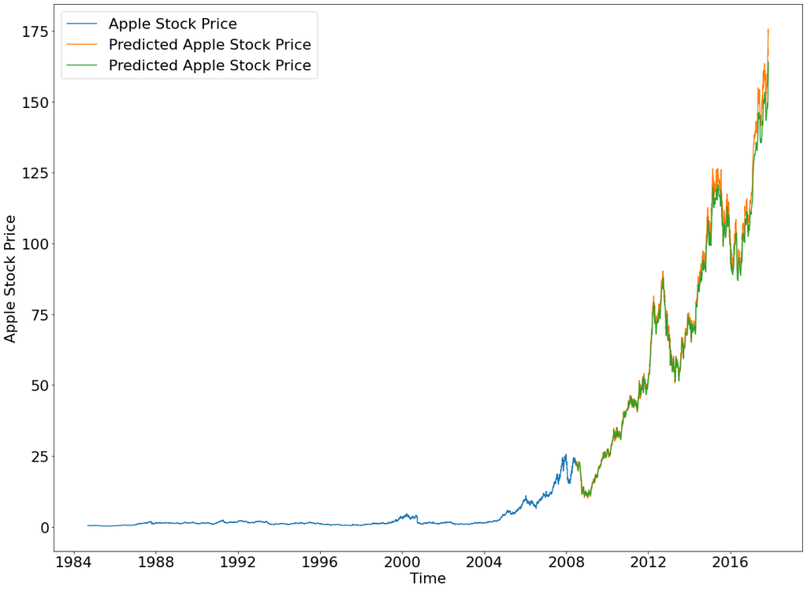

```python
#for plotting
plt.figure(figsize=(20,15))
plt.rcParams.update({'font.size': 22})
train = new_data[:6000]
valid = new_data[6000:]
valid['Predictions'] = closing_price

valid.index = new_data[6000:].index
train.index = new_data[:6000].index

plt.plot(train['Close'],label = 'Apple Stock Price')
plt.plot(valid[['Close','Predictions']],label = 'Predicted Apple Stock Price')
plt.xlabel('Time')
plt.ylabel('Apple Stock Price')
plt.legend()
plt.show()
```

From the plot we can see that the real stock price went up while our model also predicted that the price of the stock will go up. This clearly shows how powerful LSTMs are for analyzing time series and sequential data.

# Conclusion

There are a couple of other techniques of predicting stock prices such as moving averages, linear regression, K-Nearest Neighbours, ARIMA and Prophet. These are techniques that one can test on their own and compare their performance with the Keras LSTM.

The LSTM model can be tuned for various parameters such as changing the number of LSTM layers, adding dropout value or increasing the number of epochs. But are the predictions from LSTM enough to identify whether the stock price will increase or decrease? Certainly not!

As stock price is affected by the news about the company and other factors like demonetization or merger/demerger of the companies. There are certain intangible factors as well which can often be impossible to predict beforehand.

Similarly we can do this prediction for remaining companies of dataset i.e. facebook, tesla,microsoft